# Resumen de Prácticas modelos probabilisticos

Santiago Alférez (adaptado del libro de referencia)

# Introducción

Este documento es un resumen de las distribuciones de probabilidad más comunes, tanto discretas como continuas, y su implementación en RStudio. El objetivo es repasar los conceptos clave, para luego realizar ejercicios prácticos durante las prácticas de estadística.

## Variables Aleatorias Discretas (VAD)

Las VAD son aquellas que toman un número finito o contable de valores. A continuación, se presentan las distribuciones discretas más comunes y cómo calcular probabilidades, cuantiles, y realizar simulaciones en RStudio.

### Distribución Binomial

La distribución binomial modela el número de éxitos en $n$ ensayos de Bernoulli, donde cada ensayo tiene una probabilidad de éxito $p$.

- **Función de densidad**:
  $$f(x) = P(X = x) = {n \choose x} p^x
  (1-p)^{n-x}$$
- **Media**: $E(X) = np$
- **Varianza**: $V(X) = np(1-p)$

**Comandos en R**:

```r
# Probabilidad de obtener exactamente 4 éxitos en 10 ensayos con p = 0.33
dbinom(4, size=10, prob=0.33)
```

```
[1] 0.2252806
```

```r
# Probabilidad acumulada P(X <= 4)
pbinom(4, size=10, prob=0.33)
```

```
[1] 0.7936486
```

```r
# Cuantil para p = 0.1
qbinom(0.1, size=10, prob=0.33)
```

```
[1] 1
```

```r
# Simulación de 100 experimentos
rbinom(100, size=10, prob=0.33)
```

```
  [1] 5 3 6 5 1 2 1 2 3 5 1 5 1 4 3 3 6 1 6 4 5 3 3 4 2 1 3 3 4 2 6 3 5 3 4 6 5 2 4 2 3 3 2 2 2 4 4 3 1 3 3 5 2 3 7 6 2
 [58] 2 2 5 2 3 2 3 2 3 1 5 1 2 5 0 1 5 2 6 2 3 7 3 3 3 4 4 6 3 0 3 2 2 2 3 7 3 4 4 3 3 0 7
```

### Distribución Geométrica

La distribución geométrica modela el número de ensayos hasta el primer éxito en una serie de ensayos de Bernoulli.

- **Función de densidad**:
  $$f(x) = P(X = x) = p(1-p)^{x-1}$$
- **Media**: $E(X) = \frac{1}{p}$
- **Varianza**: $V(X) = \frac{1-p}{p^2}$

**Comandos en R**:

```r
# Probabilidad de que el primer éxito ocurra en el 3er ensayo
dgeom(2, prob=0.33)
```

```
[1] 0.148137
```

```r
# Probabilidad acumulada P(X <= 3)
pgeom(2, prob=0.33)
```

```
[1] 0.699237
```

```r
# Cuantil para p = 0.1
qgeom(0.1, prob=0.33)
```

```
[1] 0
```

```r
# Simulación de 100 experimentos
rgeom(100, prob=0.33)
```

```
  [1]  3  2  0  1  0  2  0  0  0  0  1  1  2  3  4  1  2  4  3  0  0  1  5  0  4  4  3  0  2  0  1  1  5  2  0  1  2  0
 [39]  2  4  8  5  2  6  0  0  3  7  2  0  1  4  2  1 11  0  0  0  3  1  0  1  5  2  0  0  5  2  0  0  5  6  0  0  5  0
 [77]  1  0  8  5  1  1  6  0  0  1  3  0  4  9  0  4  4  7  1  3  0  2  8  0
```

### Distribución de Poisson

La distribución de Poisson modela el número de eventos que ocurren en un intervalo de tiempo o espacio, con una tasa media $\lambda$.

- **Función de densidad**:
  $$f(x) = P(X = x) = \frac{e^{-\lambda}
  \lambda^x}{x!}$$
- **Media**: $E(X) = \lambda$
- **Varianza**: $V(X) = \lambda$

**Comandos en R**:

```r
# Probabilidad de que ocurran exactamente 3 eventos
dpois(3, lambda=2)
```

```
[1] 0.180447
```

```r
# Probabilidad acumulada P(X <= 3)
ppois(3, lambda=2)
```

```
[1] 0.8571235
```

```r
# Cuantil para p = 0.1
qpois(0.1, lambda=2)
```

```
[1] 0
```

```r
# Simulación de 100 experimentos
rpois(100, lambda=2)
```

```
  [1] 2 1 1 2 2 1 0 3 4 1 1 3 0 2 0 0 0 0 3 2 1 1 2 0 5 3 2 3 2 4 2 2 2 1 1 2 5 3 1 1 1 1 1 3 1 6 1 1 1 2 1 3 4 0 2 0 1
 [58] 2 2 4 4 1 3 1 1 1 2 0 2 3 5 1 0 1 7 2 1 1 0 0 0 2 2 1 1 1 1 2 4 1 2 5 3 5 0 0 2 2 1 4
```

### Distribución Binomial Negativa

La distribución binomial negativa modela el número de ensayos necesarios hasta obtener r éxitos en una serie de ensayos de Bernoulli.

- **Función de densidad**:
  $$f(x) = P(X = x) =
  \binom{x-1}{r-1}p^r(1-p)^{x-r}$$
- **Media**: $E(X) = \frac{r}{p}$
- **Varianza**: $V(X) = r\frac{1-p}{p^2}$

**Comandos en R**:

```r
# Probabilidad de necesitar exactamente 5 ensayos para 2 éxitos con p = 0.4
dnbinom(5-2, size=2, prob=0.4)  # x-r ensayos adicionales después de r éxitos
```

```
[1] 0.13824
```

```r
# Probabilidad acumulada P(X <= 5)
pnbinom(5-2, size=2, prob=0.4)
```

```
[1] 0.66304
```

```r
# Cuantil para p = 0.1
qnbinom(0.1, size=2, prob=0.4) + 2  # Añadir r para obtener x
```

```
[1] 2
```

```r
# Simulación de 100 experimentos
rnbinom(100, size=2, prob=0.4) + 2
```

```
  [1]  4  4  6  2  6  4  4  4  4  3  6  5  4  3  5  4 20  6  2  4  5  7  6  5  4  4  4  4  4  4  4  3  4  6  5  6 12  2
 [39]  4  6  3  9  2  6  5 10  8  4  4  7  6  3  3  5  3  5  2  2  4  6  5  5  4  3 13  2  3  5  2  4  4  4  2  2  4  6
 [77]  5  4  9  6  4  2  9  6  3  3  2  2  7  4  4  5  8  4  5  8  4  6  7  6
```

### Distribución Hipergeométrica

La distribución hipergeométrica modela el número de éxitos en n extracciones sin reemplazo de una población con N elementos, de los cuales k son éxitos.

- **Función de densidad**:
  $$f(x) = P(X = x) =
  \frac{\binom{k}{x}\binom{N-k}{n-x}}{\binom{N}{n}}$$
- **Media**: $E(X) = n\frac{k}{N}$
- **Varianza**: $V(X) = n\frac{k}{N}(1-\frac{k}{N})\frac{N-n}{N-1}$

**Comandos en R**:

```r
# Probabilidad de obtener 3 éxitos en 5 extracciones de una población de 20
# elementos con 8 éxitos
dhyper(3, m=8, n=12, k=5)  # m=k éxitos, n=N-k fracasos, k=n extracciones
```

```
[1] 0.2383901
```

```r
# Probabilidad acumulada P(X <= 3)
phyper(3, m=8, n=12, k=5)
```

```
[1] 0.9422085
```

```r
# Cuantil para p = 0.1
qhyper(0.1, m=8, n=12, k=5)
```

```
[1] 1
```

```r
# Simulación de 100 experimentos
rhyper(100, m=8, n=12, k=5)
```

```
  [1] 2 2 2 3 3 1 1 1 2 3 3 2 2 3 3 2 2 2 1 1 1 3 1 3 1 3 2 2 3 3 1 3 1 3 3 1 1 2 0 3 3 1 1 2 1 0 4 1 1 3 2 2 3 2 2 1 1
 [58] 2 2 3 2 0 3 3 3 2 0 1 2 1 3 2 3 2 2 1 4 2 1 2 2 2 3 2 2 1 1 1 2 4 2 2 1 2 3 0 1 0 1 2
```

## Variables Aleatorias Continuas (VAC)

Las VAC son aquellas que pueden tomar cualquier valor en un intervalo continuo. A continuación, se presentan las distribuciones continuas más comunes y cómo calcular probabilidades, cuantiles, y realizar simulaciones en RStudio.

### Distribución Uniforme

La distribución uniforme modela una variable que toma cualquier valor en un intervalo $[a, b]$ con la misma probabilidad.

- **Función de densidad**:
  $$f(x) = \frac{1}{b-a} \quad \forall x \in [a,
  b]$$
- **Media**: $E(X) = \frac{a+b}{2}$
- **Varianza**: $V(X) = \frac{(b-a)^2}{12}$

**Comandos en R**:

```r
# Probabilidad de que X esté entre 2 y 4 en una distribución uniforme [1, 5]
punif(4, min=1, max=5) - punif(2, min=1, max=5)
```

```
[1] 0.5
```

```r
# Cuantil para p = 0.1
qunif(0.1, min=1, max=5)
```

```
[1] 1.4
```

```r
# Simulación de 100 experimentos
runif(100, min=1, max=5)
```

```
  [1] 4.868205 4.744675 1.866517 2.273979 3.138844 4.266675 4.245781 3.382060 2.264954 4.777483 1.299487 1.235983
 [13] 2.155619 3.217791 4.139218 2.094865 1.789477 3.579610 1.286607 3.306070 4.550235 2.977536 3.566716 4.548739
 [25] 3.240483 4.008482 2.396295 3.485264 1.013239 4.276739 4.619320 1.365348 4.739930 1.816786 1.370352 1.441895
 [37] 1.755384 1.865238 1.173370 4.899294 2.886851 2.014945 3.047013 2.936451 3.919062 4.625166 1.882303 1.606080
 [49] 3.725659 2.861606 2.490569 3.471937 2.434766 3.708764 2.775481 4.121921 1.243492 3.146779 1.000867 4.564588
 [61] 1.497411 1.105285 2.462063 2.968160 3.373868 3.457434 2.209908 1.402683 1.806831 2.975563 2.711413 1.565925
 [73] 2.951736 2.777618 2.964154 2.566563 2.506983 4.926905 4.187408 2.445665 2.070053 3.494706 4.489434 4.858760
 [85] 3.220474 1.457460 3.181964 4.980820 1.875552 3.551292 3.824109 2.515456 3.912374 1.811844 1.770095 2.354042
 [97] 1.015156 4.501907 4.339506 4.165491
```

### Distribución Exponencial

La distribución exponencial modela el tiempo entre eventos en un proceso de Poisson con tasa $\lambda$.

- **Función de densidad**:
  $$f(x) = \lambda e^{-\lambda x} \quad \forall x
  \geq 0$$
- **Media**: $E(X) = \frac{1}{\lambda}$
- **Varianza**: $V(X) = \frac{1}{\lambda^2}$

**Comandos en R**:

```r
# Probabilidad de que X sea menor que 3
pexp(3, rate=0.5)
```

```
[1] 0.7768698
```

```r
# Cuantil para p = 0.1
qexp(0.1, rate=0.5)
```

```
[1] 0.210721
```

```r
# Simulación de 100 experimentos
rexp(100, rate=0.5)
```

```
  [1]  2.52779232  2.37257492  1.31779682  3.21114779  0.44527498  0.17726576  1.08060573  0.37431479  1.63446221
 [10]  4.52705163  3.10523458 13.72555396  3.38298781  2.15180279  0.83794017  1.06122885  1.41185293  0.98208204
 [19]  0.90914059  2.78179397  1.39660059  2.18396367  4.53855021  4.27080725  2.15498351  1.10139353  0.12407284
 [28]  1.04592681  0.93683686  0.79278267  3.70195690  1.39401190  3.93336082  0.83064501  0.19952622  0.37712171
 [37]  1.60179101  3.63756518  1.94322781  0.57511947  2.94672563  1.95028956  0.67796460  0.10777879  2.82512032
 [46]  3.67781341  1.60635032  1.44923189  7.36903543  3.00672942  0.32064057  1.91339384  0.71896268  0.37741423
 [55]  4.67696683  1.31086143  1.01387611  0.85793558  0.14782405  0.81409917  0.15915493  0.37689137  2.87243197
 [64]  0.20307750  0.27744167  0.76376884  8.49597205  0.40083886  2.86058302  2.20347392  0.32540892  0.78734046
 [73]  0.10869978  0.43560564  1.26244483  1.38968879  1.58352850  2.45322075  2.44651663  3.33855271  0.41080572
 [82]  0.29456988  2.10338766  6.67409094  4.88693847  9.48056749  3.32484488  2.15356396  8.74865339  7.69396221
 [91]  0.25444278  2.57660519  4.19085563  5.64878580  0.26044216  0.27976649  0.19779973  3.06421492  0.04849724
[100]  0.03120491
```

### Distribución Normal

La distribución normal es la más importante en estadística, modelando fenómenos naturales y procesos industriales.

- **Función de densidad**:
  $$f(x) = \frac{1}{\sigma \sqrt{2\pi}}
  e^{-\frac{1}{2} \left( \frac{x-\mu}{\sigma} \right)^2}$$
- **Media**: $E(X) = \mu$
- **Varianza**: $V(X) = \sigma^2$

**Comandos en R**:

```r
# Probabilidad de que X sea menor que 1.75 en una N(1.25, 0.46^2)
pnorm(1.75, mean=1.25, sd=0.46)
```

```
[1] 0.861472
```

```r
# Cuantil para p = 0.1
qnorm(0.1, mean=1.25, sd=0.46)
```

```
[1] 0.6604863
```

```r
# Simulación de 100 experimentos
rnorm(100, mean=1.25, sd=0.46)
```

```
  [1] 1.1161199 0.8263671 1.0826612 0.7676099 1.6992611 1.5629378 1.7838587 1.8320686 0.6666331 0.8043606 1.4999111
 [12] 0.8784400 1.1119760 0.4210277 0.5390321 0.5738242 1.0922613 0.9306021 0.4722018 1.6918082 2.3473718 1.2226727
 [23] 1.3149191 1.0772076 1.1474566 0.4534607 1.0952224 1.0033752 1.1512022 1.4432828 0.8816013 1.0920876 1.3914775
 [34] 0.6924684 1.2820692 1.2960332 1.5261279 1.5925223 1.3861117 1.0387217 1.4157355 2.0665919 1.4185104 1.6890872
 [45] 1.4090626 0.9010190 1.1918077 1.3097685 2.0143296 1.6838348 1.1638591 2.0459322 1.0701157 0.9646393 1.9190218
 [56] 0.3554726 1.8549560 0.6756236 2.3770082 0.9889875 1.7066932 2.0709125 1.5611703 0.7460374 1.5126768 1.7792423
 [67] 0.4193551 1.4636832 1.5978226 1.1131347 1.3429389 2.1176386 0.7688224 1.2205214 1.1830118 1.8354641 0.9469133
 [78] 1.0325044 0.8659965 0.7247881 1.4077050 1.2158069 0.8800597 1.0392108 0.3238479 0.6641777 0.4080814 0.9315922
 [89] 0.8778930 1.4807431 1.2564842 1.1580328 1.3794681 1.0986188 1.3026933 0.8177995 1.0067465 1.3162295 1.1010820
[100] 0.9336678
```

## Gráficas de Distribuciones

En RStudio, se pueden generar gráficos de las funciones de masa/densidad y distribución acumulada tanto para distribuciones discretas como continuas.

### Gráfica de Distribuciones Discretas

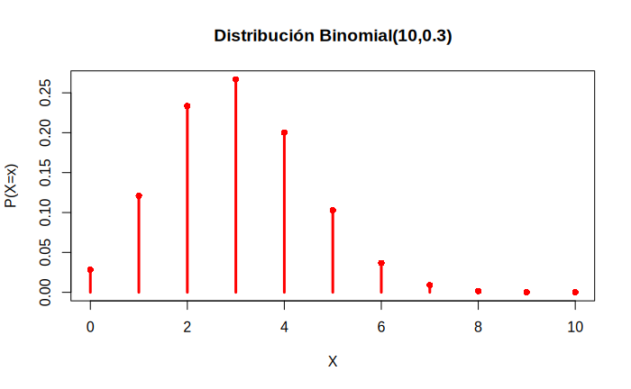

```r
# Gráfica de función de masa de probabilidad binomial
x = 0:10
fx = dbinom(x, size=10, prob=0.3)
plot(x, fx, type="h", col="red", lwd=3,
     main="Distribución Binomial(10,0.3)",
     xlab="X", ylab="P(X=x)")
points(x, fx, pch=16, col="red")
```

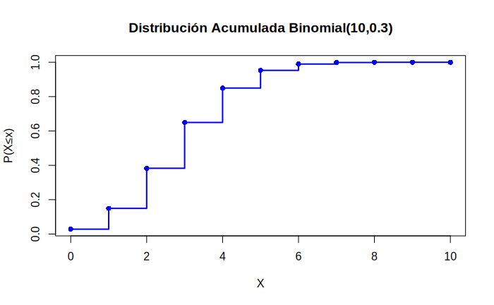

```r
# Gráfica de función de distribución acumulada binomial
Fx = pbinom(x, size=10, prob=0.3)
plot(x, Fx, type="s", col="blue", lwd=2,
     main="Distribución Acumulada Binomial(10,0.3)",
     xlab="X", ylab="P(X≤x)")
points(x, Fx, pch=16, col="blue")
```

### Gráfica de Distribuciones Continuas

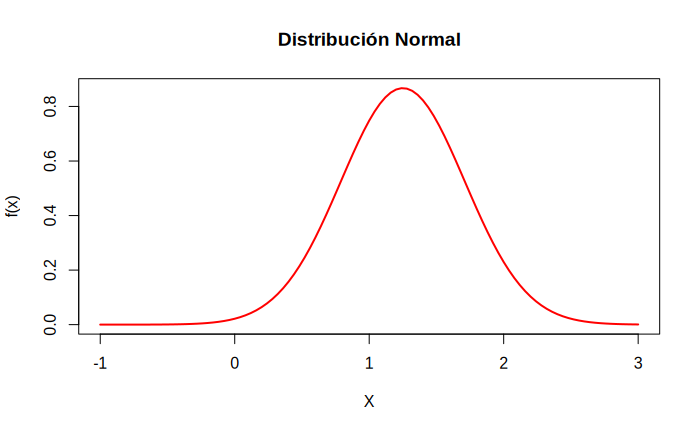

```r
# Gráfica de la función de densidad de una distribución normal
curve(dnorm(x, mean=1.25, sd=0.46), from=-1, to=3, col="red", lwd=2,
      main="Distribución Normal", xlab="X", ylab="f(x)")
```

### Gráfica de la Función de Distribución Acumulada

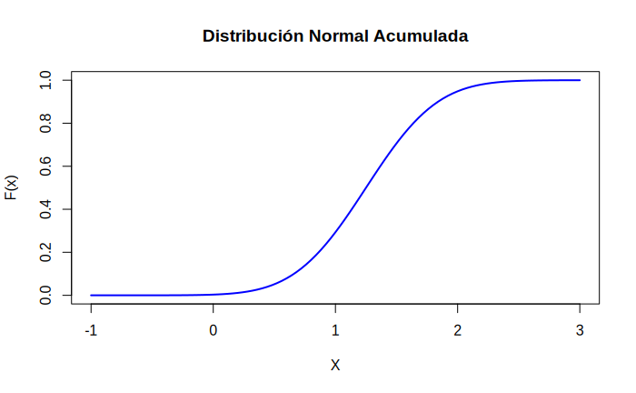

```r
# Gráfica de la función de distribución acumulada de una distribución normal
curve(pnorm(x, mean=1.25, sd=0.46), from=-1, to=3, col="blue", lwd=2,
      main="Distribución Normal Acumulada", xlab="X", ylab="F(x)")
```

## Tablas de Resumen

### Prefijos de Comandos en R

| Prefijo | Descripción | Uso | Ejemplo |
| --- | --- | --- | --- |
| `d` | Función de densidad/masa | Calcula P(X = x) | `dnorm(0, mean=0, sd=1)` → 0.3989 |
| `p` | Función de distribución | Calcula P(X ≤ x) | `pnorm(1.96, mean=0, sd=1)` → 0.975 |
| `q` | Función cuantil | Calcula x tal que P(X ≤ x) = p | `qnorm(0.975, mean=0, sd=1)` → 1.96 |
| `r` | Generación aleatoria | Genera n muestras aleatorias | `rnorm(5, mean=0, sd=1)` → [-0.2, 1.1, 0.8, -1.2, 0.5] |

### Fórmulas de Distribuciones Discretas

| Distribución | Función de Masa | Media | Varianza | Soporte | Aplicación |
| --- | --- | --- | --- | --- | --- |
| Binomial | $P(X=x)={n \choose x}p^x(1-p)^{n-x}$ | $np$ | $np(1-p)$ | x = 0,1,…,n | Éxitos en n ensayos |
| Geométrica | $P(X=x)=p(1-p)^{x-1}$ | $\frac{1}{p}$ | $\frac{1-p}{p^2}$ | x = 1,2,… | Ensayos hasta éxito |
| Poisson | $P(X=x)=\frac{e^{-\lambda}\lambda^x}{x!}$ | $\lambda$ | $\lambda$ | x = 0,1,2,… | Eventos en intervalo/región |
| Binomial Negativa | $\binom{x-1}{r-1}p^r(1-p)^{x-r}$ | $\frac{r}{p}$ | $r\frac{1-p}{p^2}$ | x ≥ r | Ensayos hasta r éxitos |
| Hipergeométrica | $\frac{\binom{k}{x}\binom{N-k}{n-x}}{\binom{N}{n}}$ | $n\frac{k}{N}$ | $n\frac{k}{N}(1-\frac{k}{N})\frac{N-n}{N-1}$ | max(0,n+k-N)≤x≤min(k,n) | Muestreo sin reemplazo |

### Fórmulas de Distribuciones Continuas

| Distribución | Función de Densidad | Media | Varianza | Soporte |
| --- | --- | --- | --- | --- |
| Uniforme | $f(x)=\frac{1}{b-a}$ | $\frac{a+b}{2}$ | $\frac{(b-a)^2}{12}$ | x ∈ [a,b] |
| Exponencial | $f(x)=\lambda e^{-\lambda x}$ | $\frac{1}{\lambda}$ | $\frac{1}{\lambda^2}$ | x ≥ 0 |
| Normal | $f(x)=\frac{1}{\sigma\sqrt{2\pi}}e^{-\frac{1}{2}(\frac{x-\mu}{\sigma})^2}$ | $\mu$ | $\sigma^2$ | x ∈ ℝ |

### Distribuciones Discretas con Ejemplos

[output not shown]

### Distribuciones Continuas con Ejemplos

| Distribución | Descripción | Comando | Parámetros | Ejemplo |
| --- | --- | --- | --- | --- |
| Uniforme | Valores con igual probabilidad | `dunif()` | `min`, `max` | `dunif(1.5, min=0, max=2)` → 0.5 |
| Exponencial | Tiempo entre eventos | `dexp()` | `rate` | `dexp(1, rate=2)` → 0.271 |
| Normal | Fenómenos naturales | `dnorm()` | `mean`, `sd` | `dnorm(0, mean=0, sd=1)` → 0.3989 |

### Comandos de Gráficas con Ejemplos

| Tipo | Gráfica | Descripción | Comando | Ejemplo |
| --- | --- | --- | --- | --- |
| Discreta | Masa | Función de masa de probabilidad | `plot(type="h")` | `plot(x, dbinom(x,10,0.3), type="h")` |
| Discreta | Acumulada | Función de distribución | `plot(type="s")` | `plot(x, pbinom(x,10,0.3), type="s")` |
| Continua | Densidad | Función de densidad | `curve(dnorm())` | `curve(dnorm(x,0,1), -3, 3)` |
| Continua | Acumulada | Función de distribución | `curve(pnorm())` | `curve(pnorm(x,0,1), -3, 3)` |

**Notas sobre gráficas discretas:** - `type="h"`: Dibuja líneas verticales (histograma) - `type="s"`: Dibuja función escalonada - `points()`: Agrega puntos en los valores discretos - Para distribuciones discretas se usa `plot()` con un vector de valores x

## Guía para Selección de Distribución

### ¿Cómo elegir la distribución adecuada?

Sigue estos pasos para identificar qué distribución de probabilidad usar:

1. **Determina si la variable es discreta o continua**
   - Discreta: Cuenta elementos o sucesos (números enteros)
   - Continua: Mide magnitudes (puede tomar cualquier valor en un intervalo)
2. **Para variables discretas, pregúntate**:
   - ¿Estás contando éxitos en un número fijo de intentos? → **Binomial**
     - Ejemplo: Número de piezas defectuosas en 100 inspecciones
     - Clave: Número fijo de intentos, cada uno con mismo p
   - ¿Estás contando intentos hasta el primer éxito? → **Geométrica**
     - Ejemplo: Número de lanzamientos hasta obtener cara
     - Clave: Interesa el número de intentos hasta éxito
   - ¿Estás contando eventos en un intervalo/región? → **Poisson**
     - Ejemplo: Número de clientes por hora, defectos por m²
     - Clave: Tasa media conocida, eventos independientes
   - ¿Estás contando éxitos hasta alcanzar un número r de ellos? → **Binomial Negativa**
     - Ejemplo: Número de ventas hasta conseguir 5 clientes premium
     - Clave: Interesa número de intentos hasta r éxitos
   - ¿Estás muestreando sin reemplazo? → **Hipergeométrica**
     - Ejemplo: Seleccionar 5 componentes de un lote de 20, donde 8 son defectuosos
     - Clave: Población finita, sin reemplazo
3. **Para variables continuas, pregúntate**:
   - ¿Todos los valores en un intervalo son igualmente probables? → **Uniforme**
     - Ejemplo: Tiempo de espera entre 0 y 10 minutos
     - Clave: Igual probabilidad en todo el intervalo
   - ¿Estás midiendo tiempo entre eventos? → **Exponencial**
     - Ejemplo: Tiempo entre llegadas de clientes
     - Clave: Tiempo entre eventos de Poisson
   - ¿Es una medida natural o industrial? → **Normal**
     - Ejemplo: Alturas, pesos, medidas de fabricación
     - Clave: Resultado de muchos factores pequeños e independientes

### Señales de alerta para cada distribución

**Binomial**: - Necesitas: número fijo de intentos (n) - Cada intento es independiente - Solo dos resultados posibles (éxito/fracaso) - Misma probabilidad de éxito en cada intento

**Poisson**: - Eventos ocurren de forma individual - Eventos son independientes - Conoces la tasa media - La ocurrencia en un intervalo no afecta a otros

**Normal**: - Datos son simétricos alrededor de la media - Medidas físicas o naturales - Resultado de muchos factores pequeños - Valores extremos son menos probables

**Exponencial**: - Tiempos de espera - Tiempo hasta el siguiente evento - Los eventos siguen distribución de Poisson - Sin “memoria” (tiempo pasado no afecta)

**Binomial Negativa**: - Se busca número de intentos hasta r éxitos - Cada intento es independiente - Misma probabilidad de éxito en cada intento - No hay límite en número de intentos

**Hipergeométrica**: - Muestreo sin reemplazo - Población finita y conocida - Número conocido de éxitos en población - La probabilidad cambia en cada extracción